# Social Network Analysis Report über Weinbewertungs-Daten

## Einleitung und Forschungsfrage

In der folgenden Arbeit wird der Datensatz “Wine Reviews”(https://www.kaggle.com/datasets/zynicide/wine-reviews/data) des Kaggle-Users “Zackthoutt” analysisert und behandelt. Der Datensatz wurde von der Website https://www.wineenthusiast.com/ gescraped und durch “Zackthoutt” auf Kaggle bereitgestellt.

Als Anreicherung wird weiterhin der Datensatz “wine-producing-countries-2023” der website: https://worldpopulationreview.com/country-rankings/wine-producing-countries verwendet. Dieser Datensatz enthält die Produktion von Wein aller Länder.

Wein ist eines der ältesten und am weitesten verbreiteten alkoholischen Getränke weltweit. Mit einer ca. 8000 Jahren alten Geschichte hat sich rund um das Thema wein eine vielfälltige und komplex Kutur gebildet. Wein und seine Vielfalt hat auch mein persönliches Interesse geweckt weshalb ich diesen Report dem Thema der Bewertung von Wein sowie seiner Produktion widmen möchte.

Die Fragen die dieser Report beantworten soll sind:

1. Welches Land stellt die meißten der bewerteten Weine?
2. Welches Land bekommt durchschnittlich die besten bewertungen?
3. Welches Land hat das beste Preis-Punkte-Verhältis?
4. Stimmt die Verteilung der bewerteten Weine mit der weltweiten Produktion (je Land) von Wein überein?
5. In welcher Relationen stehen die länder in Bezug auf die Anzahl der bewerteten Weine zueinander?

## Analysestrategie

Zur beantfortung der Fragen werden zuerst verschiedene Daten benötigt:

- Das Herkunftsland des Weines
- Der Name bzw. ein eindeutig zuzuweisender Parameter
- Die erhaltenen Punkte
- Der Preis
- Die Weinproduktion der jeweiligen Länder insgesammt
- Name des Testers

Es gibt weiterhin Faktoren die aus den gegebenen Daten errechnet werden müsse:

- Die Anzahl der Weine je Land
- Der Durchschnitsspreis von weinen je Land sowie die Punkteanzahl
- Das Verhältnis des Preis- und Punktedurchschnits je Land
- Die Ähnlichkeit bzw. Relation der verschiedenen Länder im Bezug auf die Anzahl der Weine
- Die Anzahl der getesteten Weine je nach Tester und Land

## Analyse des Datensatzes

### Data Exploration & Cleaning

Zuerst muss der Datensatz “winemag-data-130k-v2.csv” welcher die Daten für die Bewertungen der verschiedenen Weine enthält geladen werden. Ebenfalls wird der zweite Datensatz zur anreicherung geladen und formatiert.

```r
# setzen der benötigten Packages
library(readr)
library(dplyr)
library(igraph)
library(ggplot2)
library(gridExtra)
# laden des Datensatzes
winemag_data_130k_v2 <- read_csv("winemag-data-130k-v2.csv",show_col_types = FALSE)
# zuweisen des Datensatzes zu einem neue Data Frame zur weiterverarbeitung
df <- winemag_data_130k_v2

# zweiten Datensatz laden und umwandeln um ihn in der anschließenden Analyse Nutzen zu können
wineproduction_data_2023 <- read.csv("wine-producing-countries-2023.csv")
df_wine_prod <- na.omit(select(wineproduction_data_2023, country, wineProducingCountries_wineProduction))
```

```r
# um einen ersten Überblick zu erhalten werden mit head(df,10) die ersten 10 Zeilen ausgegeben
head(df,10)
```

```
## # A tibble: 10 × 14
##     ...1 country description designation points price province region_1 region_2
##    <dbl> <chr>   <chr>       <chr>        <dbl> <dbl> <chr>    <chr>    <chr>
##  1     0 Italy   Aromas inc… Vulkà Bian…     87    NA Sicily … Etna     <NA>
##  2     1 Portug… This is ri… Avidagos        87    15 Douro    <NA>     <NA>
##  3     2 US      Tart and s… <NA>            87    14 Oregon   Willame… Willame…
##  4     3 US      Pineapple … Reserve La…     87    13 Michigan Lake Mi… <NA>
##  5     4 US      Much like … Vintner's …     87    65 Oregon   Willame… Willame…
##  6     5 Spain   Blackberry… Ars In Vit…     87    15 Norther… Navarra  <NA>
##  7     6 Italy   Here's a b… Belsito         87    16 Sicily … Vittoria <NA>
##  8     7 France  This dry a… <NA>            87    24 Alsace   Alsace   <NA>
##  9     8 Germany Savory dri… Shine           87    12 Rheinhe… <NA>     <NA>
## 10     9 France  This has g… Les Natures     87    27 Alsace   Alsace   <NA>
## # ℹ 5 more variables: taster_name <chr>, taster_twitter_handle <chr>,
## #   title <chr>, variety <chr>, winery <chr>
```

Nachdem der Datensatz nun schonmal exemplarisch geladen ist, kann man sehen das dieser 14 verschiedene Spalten hat.

Diese sind:

- country
- description
- designation
- points
- price
- province
- region_1
- region_2
- taster_name
- taster_twitter_handle
- tittle
- variety
- winery

Für unsere Analyse verwenden wir jedoch nur die folgenden Spalten:

- country
- points
- price
- taster_name

### Frage 1 - Welches Land stellt die meisten der bewerteten Weine?

Um herrauszufinden welches Land die meisten Weine in der Bewertung stellt müssen wir zuerst die Spalten “country” sowie “title” aus dem Haupt Dataframe (df) extrahieren. Nun können die Weine je nach Land aufsummiert werden und in einem Balkendiagramm veranschaulicht werden.

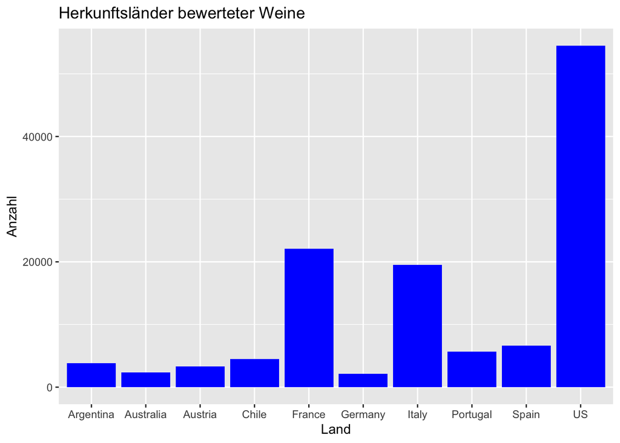

```r
# Neuen Dataframe mit den Spalten "country" und "title" bilden
df_WW <- na.omit(select(df, country, title))
# Anzahl der Einträge je Land zählen
df_WW_wines_by_country <- as.data.frame(table(df_WW$country))
# Dataframe absteigend sortieren
df_WW_wines_by_country <- df_WW_wines_by_country[order(-df_WW_wines_by_country$Freq),]

# Plot der Top 10 Länder erstellen um die prominenteste Nation zu finden
ggplot(df_WW_wines_by_country[1:10,], aes(x = Var1, y = Freq)) +
  geom_bar(stat = "identity", fill = "blue") +
  labs(title = "Herkunftsländer bewerteter Weine", x = "Land", y = "Anzahl")
```

```r
# Name des Landes und Anzahl der weine ausgeben
print(df_WW_wines_by_country)
```

```
##                      Var1  Freq
## 43                     US 54504
## 16                 France 22093
## 23                  Italy 19540
## 38                  Spain  6645
## 32               Portugal  5691
## 9                   Chile  4472
## 1               Argentina  3800
## 4                 Austria  3345
## 3               Australia  2329
## 18                Germany  2165
## 30            New Zealand  1419
## 37           South Africa  1401
## 22                 Israel   505
## 19                 Greece   466
```

[output cut: 29 more lines]

Nachdem man das Diagram sowei die Ausgabe aus der Kosole betrachtet, sieht man das die USA mit: 54504 das Land sind welche die meisten Weine Stellen.

### Frage 2 - Welches Land bekommt durchschnittlich die besten bewertungen?

Um zu errechnen welches Land durschnittlich die beste Punktzahl erhält müssen wir zuerts einen Dataframe erzeugen welcher die Spalten: “country”, “points” und “title” enthält.

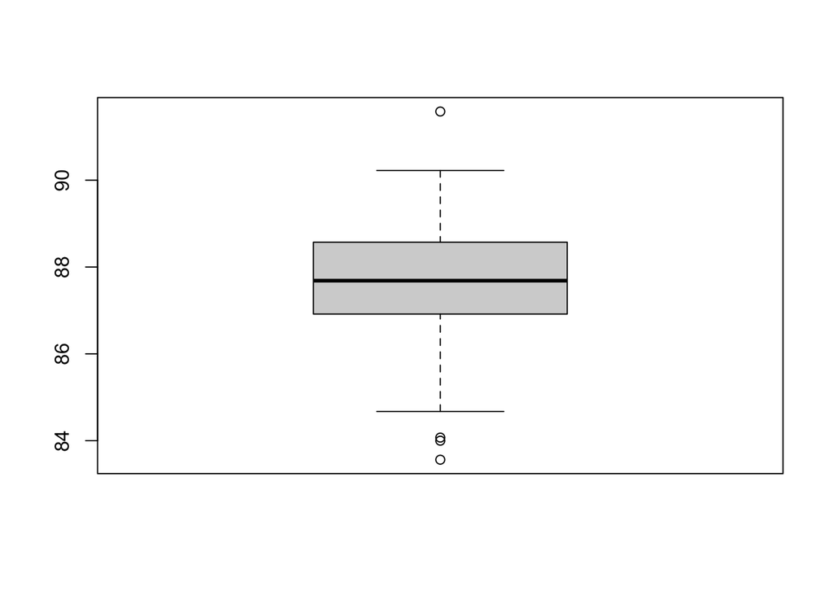

```r
# Erzeugen des Dataframes
df_WW_points <- na.omit(select(df, country,points,title))
df_WW_wines_by_country <- df_WW_wines_by_country[order(df_WW_wines_by_country$Var1),]
# Aggregation der Werte sowie die Berechnung der Durchschnittlichen Punkte Anzahl
df_WW_points_avg <- aggregate(df_WW_points$points, list(df_WW_points$country), FUN=mean)
# Alphabetisches Sortieren des DF
df_WW_points_avg <- df_WW_points_avg[order(df_WW_points_avg$Group.1),]
# visualisiserung der Verteilung der Punktedurchschnitte
boxplot(df_WW_points_avg$x)
```

Durch diesen Boxplot kann man sehen das der Durchschnitt der durschnittlichen Punktezahl bei ca. 87.65 liegt, es gibt weiterhin outlier die von <84 bis >90 liegen. Um dies besser zu veranschaulichen bedarf es jedoch einer anderen Visualisierungsform wie beispielsweise einem Balkendiagramm.

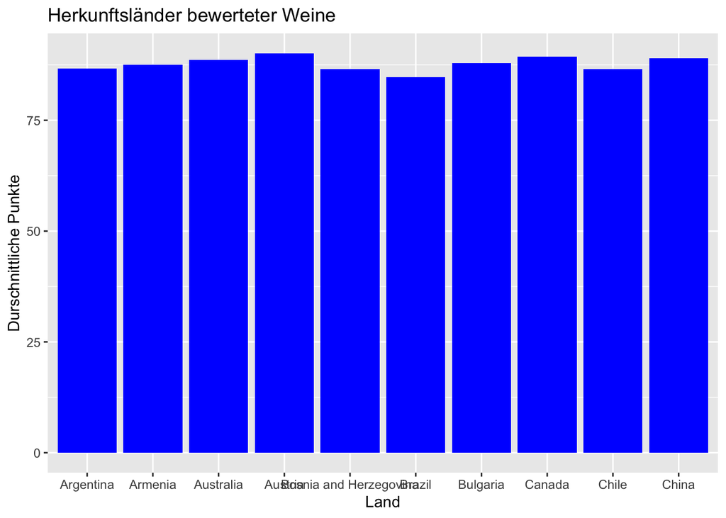

```r
ggplot(df_WW_points_avg[1:10,], aes(x = Group.1, y = x)) +
  geom_bar(stat = "identity", fill = "blue") +
  labs(title = "Herkunftsländer bewerteter Weine", x = "Land", y = "Durschnittliche Punkte")
```

```r
# Absteigend sortieren und ausgeben des DF
print(head(df_WW_points_avg[order(-df_WW_points_avg$x),],20))
```

```
##         Group.1        x
## 15      England 91.58108
## 21        India 90.22222
## 4       Austria 90.10135
## 18      Germany 89.85173
## 8        Canada 89.36965
## 20      Hungary 89.19178
## 10        China 89.00000
## 16       France 88.84511
## 25   Luxembourg 88.66667
## 3     Australia 88.58051
## 29      Morocco 88.57143
## 39  Switzerland 88.57143
## 43           US 88.56372
## 23        Italy 88.56223
## 22       Israel 88.47129
## 30  New Zealand 88.30303
## 32     Portugal 88.25022
## 40       Turkey 88.08889
## 36     Slovenia 88.06897
## 37 South Africa 88.05639
```

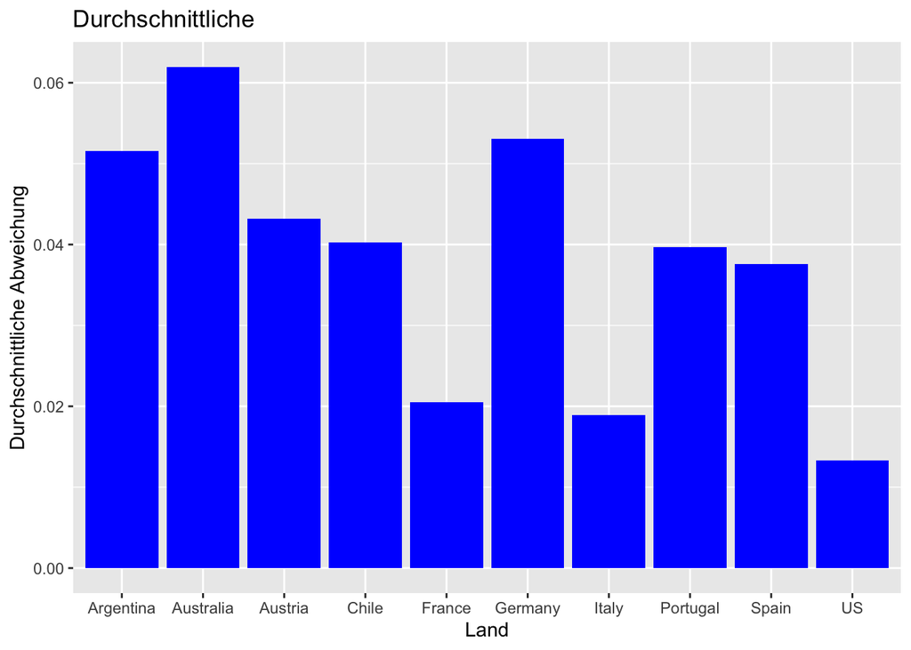

```r
# Standardtabweichnung berechnene
df_WW_points_SEM <- aggregate(df_WW_points$points, list(df_WW_points$country), FUN=sd)
# SEM berechnen
df_WW_points_SEM$x <- df_WW_points_SEM$x / sqrt(df_WW_wines_by_country$Freq)
#DF absteigend sortieren
df_WW_points_SEM <- df_WW_points_SEM[order(df_WW_points_SEM$x),]
# Balkendiagramm der top 10 erstellen
ggplot(df_WW_points_SEM[1:10,], aes(x = Group.1, y = x)) +
  geom_bar(stat = "identity", fill = "blue") +
  labs(title = "Durchschnittliche", x = "Land", y = "Durchschnittliche Abweichung")
```

```r
print(head(df_WW_points_SEM))
```

```
##     Group.1          x
## 43       US 0.01334202
## 23    Italy 0.01895586
## 16   France 0.02048225
## 38    Spain 0.03761533
## 32 Portugal 0.03971597
## 9     Chile 0.04026974
```

Ziehen wir nun mit in betracht das auch eine geringe Abweichung der gegebenen Werte vom Durchschnitt eine wichte Rolle spielt so können wir feststellen das die USA das Land sind bei welchem die geringste Abweichung von der Durschnittlichen Punkte zu erwarten ist.

Um die Frage zu beantworten “Welches Land bekommt durschnittlich die besten Bewertungen?” kann man also sagen das zwar England das Land mit dem höchsten durschnittlichen Score ist (91,581) jedoch die USA das Land sind bei welchem es die niedrigste zu erwartende Streuung vom Durschnitt gibt (0.0133).

### Frage 3 - Welches Land hat das beste Punkte-Preis-Verhältnis?

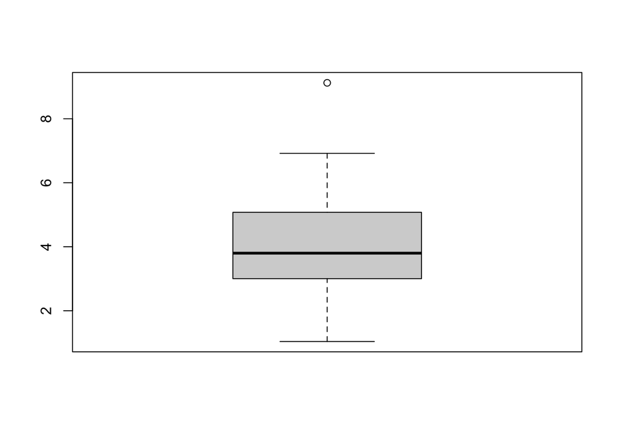

```r
# erstellen des bebötigten DF zur berechnung des Durschnittspreis
df_WW_price <- select(df, country, price)
df_WW_price$price[is.na(df_WW_price$price)] <-0.0
# berechnung des Durschnittspreis
df_WW_price_avg <- aggregate(df_WW_price$price, list(df_WW_price$country), FUN=mean)
df_WW_price_avg <- df_WW_price_avg[order(df_WW_price_avg$Group.1),]
# erstellen der neuen Spalte für das Preis-Punkte-Verhältnis
df_WW_price_avg$PPV <- df_WW_points_avg$x / df_WW_price_avg$x
# sortieren nach PPV
df_WW_price_avg <- df_WW_price_avg[order(-df_WW_price_avg$PPV),]

# visualisieren der Ergebnisse sowie ausgabe in die Konsole
boxplot(df_WW_price_avg$PPV)
```

```r
print(df_WW_price_avg)
```

```
##                   Group.1         x      PPV
## 14                  Egypt  0.000000      Inf
## 41                Ukraine  9.214286 9.124031
## 5  Bosnia and Herzegovina 12.500000 6.920000
## 21                  India 13.333333 6.766667
## 2                 Armenia 14.500000 6.034483
## 7                Bulgaria 14.645390 6.004358
## 33                Romania 15.241667 5.668671
## 26              Macedonia 15.583333 5.572193
## 35               Slovakia 16.000000 5.437500
## 12                 Cyprus 16.272727 5.357542
## 28                Moldova 16.745763 5.207490
## 10                  China 18.000000 4.944444
## 17                Georgia 18.872093 4.646334
## 31                   Peru 18.062500 4.626298
```

[output cut: 29 more lines]

Wir können nun sehen das die Ukraine das Land ist wessen Weine das beste Punkte-Preis-Verhältnis aufweisen (9,124), hierbei ist jedoch erneut zu beachten das die Sample Size eine wichtige rolle Spielt und möglicherweise das Ergebnis verzehrt. Das schlechteste Verhältnis hat die Schweiz mit ca. 1,039. Der durschnittliche Score liegt bei ca. 3,8.

### Frage 4 - Stimmt die Verteilung der bewerteten Weine mit der weltweiten Produktion (je Land) von Wein überein?

Um herrauszufinden ob die Herkunft der bewerteten Weine mit der Produktion von wein zusammenhängt verwenden wir hier einen 2. Datensatz welcher die weltweite Produktion von Wein abbildet.

Zuerst müssen wir nun die Verteilung der weltweiten Weinporduktion betrachten und danach mit der Anzahl der bewerteten Weine vergleichen.

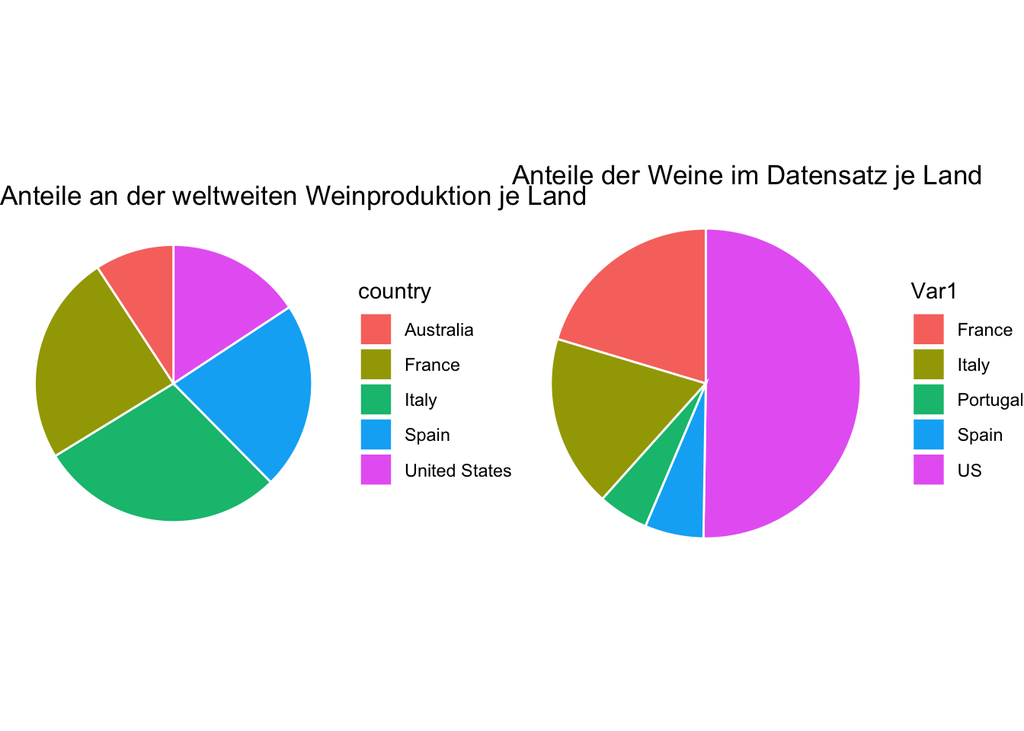

```r
# festlegen der Zahlennotation
options(scipen = 999)
# Berechnen der Anteile der verschiedenen Länder an der weltweiten Weinproduktion in Prozent
df_wine_prod$percent <- df_wine_prod$wineProducingCountries_wineProduction/sum(df_wine_prod$wineProducingCountries_wineProduction) * 100
# Das selbe für die bewerteten Weine
df_WW_wines_by_country$percent <-df_WW_wines_by_country$Freq / sum(df_WW_wines_by_country$Freq) * 100
# DF sortieren
df_wine_prod <- df_wine_prod[order(-df_wine_prod$percent),]
df_WW_wines_by_country <- df_WW_wines_by_country[order(-df_WW_wines_by_country$percent),]

# Kuchendiagramm für die weltweiten Daten
pie_WW_prod <- ggplot(df_wine_prod[1:5,], aes(x = "", y = percent, fill = country)) +
  geom_bar(stat = "identity", width = 1, color = "white") +
  coord_polar("y") +
  theme_void() +
  ggtitle("Anteile an der weltweiten Weinproduktion je Land")

# Kuchendiagramm für die Weine aus dem Review-Datensatz
pie_WW_set <- ggplot(df_WW_wines_by_country[1:5,], aes(x = "", y = percent, fill = Var1)) +
  geom_bar(stat = "identity", width = 1, color = "white") +
  coord_polar("y") +
  theme_void() +
  ggtitle("Anteile der Weine im Datensatz je Land")

grid.arrange(pie_WW_prod, pie_WW_set, ncol = 2)
```

Hier können wir nun beobachten das das Verhältnis der bewerteten Weine sich deutlich von dem der tatsächlichen weltweite Produktion unterscheidet. Diese Disparität kann vielerlei Gründe haben, zum einen ist das Magazin von welchem die Daten erhoben wurden Amerekanisch weshalb ein gewisser Bias in die Richtung zu erwarten war. Die anderen Unterschiede jedoch sind schwerer zu erklären wie zum Beispiel das Australien der weltweit fünft größte Weinproduzent ist jedoch bei den bewerteten Weinen nicht unter den Top 5 auftritt. Desweiteren werden anscheinend überproportional mehr Portugisische Weine bewertet als Portugal insgesammt anteilig produziert.

### Frage 5 - In welcher Relationen stehen die Länder in Bezug auf die Anzahl der bewerteten Weine zueinander?

Um herrauszufinden in welcher Relation die verschiedenen Länder zueinander stehen, im Bezug auf den Anteil ihrer Weine im Datensatz müssen wir die Daten zuerst nach Kontinent sortieren um sie dann weiter zu verarbeiten. Dadurch das wir so viele verschiedene Länder und verbindungen haben ist es sinvoller Subnetze für die verschiednen Kontinente zu erstellen da so eine bessere übersicht herscht.

```r
# zuerst legen wir listen mit allen Länder je kontinent an um anschließend die Daten zu vergleichen, hierbei ist darauf zu achten das die Namen der Länder im Datensatz exact die selben wie in den Listen ist

# Länder in Asien
asia_countries <- c(
  "Afghanistan", "Armenia", "Azerbaijan", "Bahrain", "Bangladesh", "Bhutan",
  "Brunei", "Cambodia", "China", "Cyprus", "Georgia", "India", "Indonesia",
  "Iran", "Iraq", "Israel", "Japan", "Jordan", "Kazakhstan", "Kuwait",
  "Kyrgyzstan", "Laos", "Lebanon", "Malaysia", "Maldives", "Mongolia",
  "Myanmar", "Nepal", "North Korea", "Oman", "Pakistan", "Palestine",
  "Philippines", "Qatar", "Saudi Arabia", "Singapore", "South Korea",
  "Sri Lanka", "Syria", "Taiwan", "Tajikistan", "Thailand", "Timor-Leste",
  "Turkey", "Turkmenistan", "United Arab Emirates", "Uzbekistan",
  "Vietnam", "Yemen"
)

# Länder in Europa
europe_countries <- c(
  "Albania", "Andorra", "Austria", "Belarus", "Belgium",
  "Bosnia and Herzegovina", "Bulgaria", "Croatia", "Cyprus",
  "Czech Republic", "Denmark", "Estonia", "Finland", "France",
  "Germany", "Greece", "Hungary", "Iceland", "Ireland", "Italy",
  "Kosovo", "Latvia", "Liechtenstein", "Lithuania", "Luxembourg",
  "Malta", "Moldova", "Monaco", "Montenegro", "Netherlands",
  "Macedonia", "Norway", "Poland", "Portugal", "Romania",
  "Russia", "San Marino", "Serbia", "Slovakia", "Slovenia",
  "Spain", "Sweden", "Switzerland", "Ukraine", "England",
  "Vatican City"
)

# Länder in Afrika
africa_countries <- c(
  "Algeria", "Angola", "Benin", "Botswana", "Burkina Faso", "Burundi",
  "Cabo Verde", "Cameroon", "Central African Republic", "Chad",
  "Comoros", "Democratic Republic of the Congo", "Djibouti", "Egypt",
  "Equatorial Guinea", "Eritrea", "Eswatini", "Ethiopia", "Gabon",
  "Gambia", "Ghana", "Guinea", "Guinea-Bissau", "Ivory Coast",
  "Kenya", "Lesotho", "Liberia", "Libya", "Madagascar", "Malawi",
  "Mali", "Mauritania", "Mauritius", "Morocco", "Mozambique",
  "Namibia", "Niger", "Nigeria", "Rwanda", "Sao Tome and Principe",
  "Senegal", "Seychelles", "Sierra Leone", "Somalia", "South Africa",
  "South Sudan", "Sudan", "Tanzania", "Togo", "Tunisia", "Uganda",
  "Zambia", "Zimbabwe"
)

# Länder in Nord Amerika
north_america_countries <- c(
  "Canada", "US", "Mexico", "Guatemala", "Honduras",
  "El Salvador", "Nicaragua", "Costa Rica", "Panama", "Belize",
  "Cuba", "Jamaica", "Haiti", "Dominican Republic", "Puerto Rico",
  "Bahamas", "Trinidad and Tobago", "Barbados", "Saint Lucia",
  "Grenada", "Antigua and Barbuda", "Saint Vincent and the Grenadines",
  "Saint Kitts and Nevis"
)

# Länder in Süd Amerika
south_america_countries <- c(
  "Argentina", "Brazil", "Chile", "Colombia", "Ecuador", "Peru",
  "Bolivia", "Paraguay", "Uruguay", "Venezuela", "Guyana", "Suriname",
  "French Guiana", "Falkland Islands"
)

# Länder in Ozianien
oceania_countries <- c(
  "Australia", "New Zealand", "Fiji", "Papua New Guinea",
  "Solomon Islands", "Vanuatu", "New Caledonia", "French Polynesia",
  "Samoa", "Tonga", "Kiribati", "Tuvalu", "Micronesia",
  "Marshall Islands", "Palau", "Nauru"
)

# zuerst werden die spalte country in df mit den länderlisten abgegleicht, trift die Kondition zu so werden sie dem jeweiligen neun Kontinenten df zugewiesen

# Süd Amerika
df_SA <- df[df$country %in% south_america_countries,]
df_SA_wines_by_country <- as.data.frame(table(df_SA$country))
df_SA_wines_by_country <- df_SA_wines_by_country[order(-df_SA_wines_by_country$Freq),]

# Europa
df_EU <- df[df$country %in% europe_countries,]
df_EU_wines_by_country <- as.data.frame(table(df_EU$country))
df_EU_wines_by_country <- df_EU_wines_by_country[order(-df_EU_wines_by_country$Freq),]

# Nord Amerika
df_NA <- df[df$country %in% north_america_countries,]
df_NA_wines_by_country <- as.data.frame(table(df_NA$country))
df_NA_wines_by_country <- df_NA_wines_by_country[order(-df_NA_wines_by_country$Freq),]

# Afrika
df_AF <- df[df$country %in% africa_countries,]
df_AF_wines_by_country <- as.data.frame(table(df_AF$country))
df_AF_wines_by_country <- df_AF_wines_by_country[order(-df_AF_wines_by_country$Freq),]

# Ozianien
df_OZ <- df[df$country %in% oceania_countries,]
df_OZ_wines_by_country <- as.data.frame(table(df_OZ$country))
df_OZ_wines_by_country <- df_OZ_wines_by_country[order(-df_OZ_wines_by_country$Freq),]

# Asien
df_AS <- df[df$country %in% asia_countries,]
df_AS_wines_by_country <- as.data.frame(table(df_AS$country))
df_AS_wines_by_country <- df_AS_wines_by_country[order(-df_AS_wines_by_country$Freq),]

# hier werden nun die Spalten jeweils umbenannt um besser mit ihnen weiterarbeiten zu können
df_SA_wines_by_country <- df_SA_wines_by_country %>% rename(Country = Var1, Weight = Freq)
df_EU_wines_by_country <- df_EU_wines_by_country %>% rename(Country = Var1, Weight = Freq)
df_NA_wines_by_country <- df_NA_wines_by_country %>% rename(Country = Var1, Weight = Freq)
df_AF_wines_by_country <- df_AF_wines_by_country %>% rename(Country = Var1, Weight = Freq)
df_OZ_wines_by_country <- df_OZ_wines_by_country %>% rename(Country = Var1, Weight = Freq)
df_AS_wines_by_country <- df_AS_wines_by_country %>% rename(Country = Var1, Weight = Freq)
```

Der nächste Schritt ist nun die Graphen für die jeweiligen Kontinente zu erstellen. Das verfahren wird nun exemplarisch an Süd Amerika veranschaulicht, die anderen Graphen werden auf die exakt selbe Weise erstellt.

```r
# adjancy matrix erstellen
adj_SA <- tibble( country_1=character(),country_2=character(),adj=numeric()
)
# zähler für die folgende While schleife aufsetzen
i <- nrow(df_SA_wines_by_country)
z <- nrow(df_SA_wines_by_country)

#zuweisen der Länder zueinander damit jede beziehung zwischen jedem Land berechnet werden kann
while (i >= 1) {

  country_1 <- df_SA_wines_by_country[i, 1]
  country_2 <- df_SA_wines_by_country[z, 1]

  # adjacency berechnen, wie ähnlch die Anzahl der weine ist
  adj <- ifelse(
    ifelse(df_SA_wines_by_country[z, 2] > df_SA_wines_by_country[i, 2],
           df_SA_wines_by_country[z, 2] / df_SA_wines_by_country[i, 2],
           df_SA_wines_by_country[i, 2] / df_SA_wines_by_country[z, 2]) > 10,
    NA,
    ifelse(df_SA_wines_by_country[z, 2] > df_SA_wines_by_country[i, 2],
           df_SA_wines_by_country[z, 2] / df_SA_wines_by_country[i, 2],
           df_SA_wines_by_country[i, 2] / df_SA_wines_by_country[z, 2])
  )

  # Reihe formatieren und in die Matrix einfügen
  row_data <- tibble(country_1 = country_1, country_2 = country_2, adj = adj)
  adj_SA <- bind_rows(adj_SA, row_data)

  # Counter setzen
  z <- z - 1

  if (z == 0) {
    i <- i - 1
    z <- i
  }
}
# NA Werte entfernen und den leeren Graphen erstellen
adj_SA <-na.omit(adj_SA)
graph_SA <- graph.empty()

# größe der Nodes berechnen (nach totaler Anzahl der Weine)
vertex_size_SA <- tibble(Country = character(),Size = numeric())
i <- nrow(df_SA_wines_by_country)
while(i > 0){
  Country = df_SA_wines_by_country[i,1]
  Size <- ifelse(df_SA_wines_by_country[i,2]/100 > 2, (df_SA_wines_by_country[i,2]/1000)+7, 7)
  add_row(vertex_size_SA, Country=character(), Size=numeric())
  row_data <- tibble(Country=Country,Size=Size)
  vertex_size_SA <- bind_rows(vertex_size_SA,row_data)
  i <- i - 1
  vertex_size_SA <- vertex_size_SA[order(vertex_size_SA$Size, decreasing = TRUE),]
}

# Nodes hinzufügen
graph_SA <- add_vertices(graph_SA, n = nrow(df_SA_wines_by_country), name = df_SA_wines_by_country$Country, size = vertex_size_SA$Size)

# Edges hinzufügen
i<-nrow(adj_SA)
while (i > 0) {
  graph_SA <- add_edges(graph_SA, edges = as.matrix(adj_SA[i, c("country_1", "country_2")]))
  i <- i - 1

}
```

```r
adj_EU <- tibble( country_1=character(),country_2=character(),adj=numeric()
)
i <- nrow(df_EU_wines_by_country)
z <- nrow(df_EU_wines_by_country)


while (i >= 1) {

  country_1 <- df_EU_wines_by_country[i, 1]
  country_2 <- df_EU_wines_by_country[z, 1]

  adj <- ifelse(
    ifelse(df_EU_wines_by_country[z, 2] > df_EU_wines_by_country[i, 2],
           df_EU_wines_by_country[z, 2] / df_EU_wines_by_country[i, 2],
           df_EU_wines_by_country[i, 2] / df_EU_wines_by_country[z, 2]) > 10,
    NA,
    ifelse(df_EU_wines_by_country[z, 2] > df_EU_wines_by_country[i, 2],
           df_EU_wines_by_country[z, 2] / df_EU_wines_by_country[i, 2],
           df_EU_wines_by_country[i, 2] / df_EU_wines_by_country[z, 2])
  )


  row_data <- tibble(country_1 = country_1, country_2 = country_2, adj = adj)
  adj_EU <- bind_rows(adj_EU, row_data)

  z <- z - 1

  if (z == 0) {
    i <- i - 1
    z <- i
  }
}
adj_EU <-na.omit(adj_EU)
graph_EU <- graph.empty()

vertex_size_EU <- tibble(Country = character(),Size = numeric())
i <- nrow(df_EU_wines_by_country)
while(i > 0){
  Country = df_EU_wines_by_country[i,1]
  Size <- ifelse(df_EU_wines_by_country[i,2]/1000 > 2, (df_EU_wines_by_country[i,2]/1000)+7, 7)
  add_row(vertex_size_EU, Country=character(), Size=numeric())
  row_data <- tibble(Country=Country,Size=Size)
  vertex_size_EU <- bind_rows(vertex_size_EU,row_data)
  i <- i - 1
  vertex_size_EU <- vertex_size_EU[order(vertex_size_EU$Size, decreasing = TRUE),]
}

graph_EU <- add_vertices(graph_EU, n = nrow(df_EU_wines_by_country), name = df_EU_wines_by_country$Country, size = vertex_size_EU$Size)

i<-nrow(adj_EU)
while (i > 0) {
  graph_EU <- add_edges(graph_EU, edges = as.matrix(adj_EU[i, c("country_1", "country_2")]))
  i <- i - 1

}
```

```r
adj_NA <- tibble( country_1=character(),country_2=character(),adj=numeric()
)
i <- nrow(df_NA_wines_by_country)
z <- nrow(df_NA_wines_by_country)


while (i >= 1) {

  country_1 <- df_NA_wines_by_country[i, 1]
  country_2 <- df_NA_wines_by_country[z, 1]

  adj <- ifelse(
    ifelse(df_NA_wines_by_country[z, 2] > df_NA_wines_by_country[i, 2],
           df_NA_wines_by_country[z, 2] / df_NA_wines_by_country[i, 2],
           df_NA_wines_by_country[i, 2] / df_NA_wines_by_country[z, 2]) > 10,
    NA,
    ifelse(df_NA_wines_by_country[z, 2] > df_NA_wines_by_country[i, 2],
           df_NA_wines_by_country[z, 2] / df_NA_wines_by_country[i, 2],
           df_NA_wines_by_country[i, 2] / df_NA_wines_by_country[z, 2])
  )


  row_data <- tibble(country_1 = country_1, country_2 = country_2, adj = adj)
  adj_NA <- bind_rows(adj_NA, row_data)

  z <- z - 1

  if (z == 0) {
    i <- i - 1
    z <- i
  }
}
adj_NA <-na.omit(adj_NA)
graph_NA <- graph.empty()

vertex_size_NA <- tibble(Country = character(),Size = numeric())
i <- nrow(df_NA_wines_by_country)
while(i > 0){
  Country = df_NA_wines_by_country[i,1]
  Size <- ifelse(df_NA_wines_by_country[i,2]/1000 > 2, (df_NA_wines_by_country[i,2]/1000)+7, 7)
  add_row(vertex_size_NA, Country=character(), Size=numeric())
  row_data <- tibble(Country=Country,Size=Size)
  vertex_size_NA <- bind_rows(vertex_size_NA,row_data)
  i <- i - 1
  vertex_size_NA <- vertex_size_NA[order(vertex_size_NA$Size, decreasing = TRUE),]
}

graph_NA <- add_vertices(graph_NA, n = nrow(df_NA_wines_by_country), name = df_NA_wines_by_country$Country, size = vertex_size_NA$Size)

i<-nrow(adj_NA)
while (i > 0) {
  graph_NA <- add_edges(graph_NA, edges = as.matrix(adj_NA[i, c("country_1", "country_2")]))
  i <- i - 1

}
```

```r
adj_AS <- tibble( country_1=character(),country_2=character(),adj=numeric()
)
i <- nrow(df_AS_wines_by_country)
z <- nrow(df_AS_wines_by_country)


while (i >= 1) {

  country_1 <- df_AS_wines_by_country[i, 1]
  country_2 <- df_AS_wines_by_country[z, 1]

  adj <- ifelse(
    ifelse(df_AS_wines_by_country[z, 2] > df_AS_wines_by_country[i, 2],
           df_AS_wines_by_country[z, 2] / df_AS_wines_by_country[i, 2],
           df_AS_wines_by_country[i, 2] / df_AS_wines_by_country[z, 2]) > 10,
    NA,
    ifelse(df_AS_wines_by_country[z, 2] > df_AS_wines_by_country[i, 2],
           df_AS_wines_by_country[z, 2] / df_AS_wines_by_country[i, 2],
           df_AS_wines_by_country[i, 2] / df_AS_wines_by_country[z, 2])
  )


  row_data <- tibble(country_1 = country_1, country_2 = country_2, adj = adj)
  adj_AS <- bind_rows(adj_AS, row_data)

  z <- z - 1

  if (z == 0) {
    i <- i - 1
    z <- i
  }
}
adj_AS <-na.omit(adj_AS)
graph_AS <- graph.empty()

vertex_size_AS <- tibble(Country = character(),Size = numeric())
i <- nrow(df_AS_wines_by_country)
while(i > 0){
  Country = df_AS_wines_by_country[i,1]
  Size <- ifelse(df_AS_wines_by_country[i,2]/100 > 5, (df_AS_wines_by_country[i,2]/100)+7, 7)
  add_row(vertex_size_AS, Country=character(), Size=numeric())
  row_data <- tibble(Country=Country,Size=Size)
  vertex_size_AS <- bind_rows(vertex_size_AS,row_data)
  i <- i - 1
  vertex_size_AS <- vertex_size_AS[order(vertex_size_AS$Size, decreasing = TRUE),]
}

graph_AS <- add_vertices(graph_AS, n = nrow(df_AS_wines_by_country), name = df_AS_wines_by_country$Country, size = vertex_size_AS$Size)

i<-nrow(adj_AS)
while (i > 0) {
  graph_AS <- add_edges(graph_AS, edges = as.matrix(adj_AS[i, c("country_1", "country_2")]))
  i <- i - 1
}
```

```r
adj_AF <- tibble( country_1=character(),country_2=character(),adj=numeric()
)
i <- nrow(df_AF_wines_by_country)
z <- nrow(df_AF_wines_by_country)

adj_AF <- tibble()

while (i >= 1) {

  country_1 <- df_AF_wines_by_country[i, 1]
  country_2 <- df_AF_wines_by_country[z, 1]

  adj <- ifelse(
    ifelse(df_AF_wines_by_country[z, 2] > df_AF_wines_by_country[i, 2],
           df_AF_wines_by_country[z, 2] / df_AF_wines_by_country[i, 2],
           df_AF_wines_by_country[i, 2] / df_AF_wines_by_country[z, 2]) > 10,
    NA,
    ifelse(df_AF_wines_by_country[z, 2] > df_AF_wines_by_country[i, 2],
           df_AF_wines_by_country[z, 2] / df_AF_wines_by_country[i, 2],
           df_AF_wines_by_country[i, 2] / df_AF_wines_by_country[z, 2])
  )


  row_data <- tibble(country_1 = country_1, country_2 = country_2, adj = adj)
  adj_AF <- bind_rows(adj_AF, row_data)

  z <- z - 1

  if (z == 0) {
    i <- i - 1
    z <- i
  }
}
adj_AF <-na.omit(adj_AF)
graph_AF <- graph.empty()

vertex_size_AF <- tibble(Country = character(),Size = numeric())
i <- nrow(df_AF_wines_by_country)
while(i > 0){
  Country = df_AF_wines_by_country[i,1]
  Size <- ifelse(df_AF_wines_by_country[i,2]/1000 > 2, (df_AF_wines_by_country[i,2]/1000)+7, 7)
  add_row(vertex_size_AF, Country=character(), Size=numeric())
  row_data <- tibble(Country=Country,Size=Size)
  vertex_size_AF <- bind_rows(vertex_size_AF,row_data)
  i <- i - 1
  vertex_size_AF <- vertex_size_AF[order(vertex_size_AF$Size, decreasing = TRUE),]
}

graph_AF <- add_vertices(graph_AF, n = nrow(df_AF_wines_by_country), name = df_AF_wines_by_country$Country, size = vertex_size_AF$Size)

i<-nrow(adj_AF)
while (i > 0) {
  graph_AF <- add_edges(graph_AF, edges = as.matrix(adj_AF[i, c("country_1", "country_2")]))
  i <- i - 1

}
```

```r
adj_OZ <- tibble( country_1=character(),country_2=character(),adj=numeric()
)
i <- nrow(df_OZ_wines_by_country)
z <- nrow(df_OZ_wines_by_country)

adj_OZ <- tibble()

while (i >= 1) {

  country_1 <- df_OZ_wines_by_country[i, 1]
  country_2 <- df_OZ_wines_by_country[z, 1]

  adj <- ifelse(
    ifelse(df_OZ_wines_by_country[z, 2] > df_OZ_wines_by_country[i, 2],
           df_OZ_wines_by_country[z, 2] / df_OZ_wines_by_country[i, 2],
           df_OZ_wines_by_country[i, 2] / df_OZ_wines_by_country[z, 2]) > 10,
    NA,
    ifelse(df_OZ_wines_by_country[z, 2] > df_OZ_wines_by_country[i, 2],
           df_OZ_wines_by_country[z, 2] / df_OZ_wines_by_country[i, 2],
           df_OZ_wines_by_country[i, 2] / df_OZ_wines_by_country[z, 2])
  )


  row_data <- tibble(country_1 = country_1, country_2 = country_2, adj = adj)
  adj_OZ <- bind_rows(adj_OZ, row_data)

  z <- z - 1

  if (z == 0) {
    i <- i - 1
    z <- i
  }
}
adj_OZ <-na.omit(adj_OZ)
graph_OZ <- graph.empty()

vertex_size_OZ <- tibble(Country = character(),Size = numeric())
i <- nrow(df_OZ_wines_by_country)
while(i > 0){
  Country = df_OZ_wines_by_country[i,1]
  Size <- ifelse(df_OZ_wines_by_country[i,2]/1000 > 2, (df_OZ_wines_by_country[i,2]/1000)+7, 7)
  add_row(vertex_size_OZ, Country=character(), Size=numeric())
  row_data <- tibble(Country=Country,Size=Size)
  vertex_size_OZ <- bind_rows(vertex_size_OZ,row_data)
  i <- i - 1
  vertex_size_OZ <- vertex_size_OZ[order(vertex_size_OZ$Size, decreasing = TRUE),]
}

graph_OZ <- add_vertices(graph_OZ, n = nrow(df_OZ_wines_by_country), name = df_OZ_wines_by_country$Country, size = vertex_size_OZ$Size)

i<-nrow(adj_OZ)
while (i > 0) {
  graph_OZ <- add_edges(graph_OZ, edges = as.matrix(adj_OZ[i, c("country_1", "country_2")]))
  i <- i - 1

}
```

#### Europa

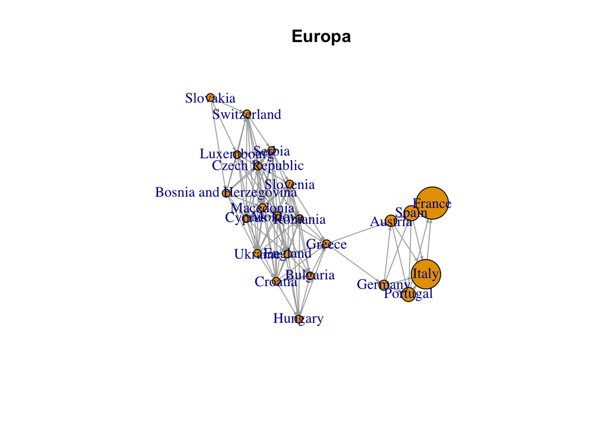

```r
layout = layout_with_graphopt(graph_EU)
plot(simplify(graph_EU), edge.arrow.size = 0.2,layout = layout, main = "Europa")
```

#### Asien

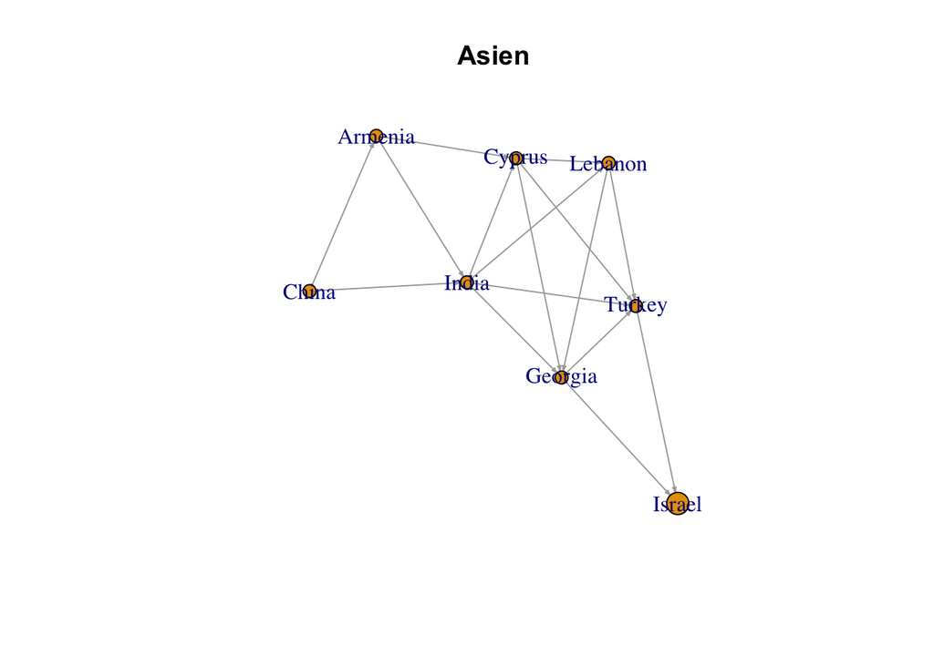

```r
layout = layout_with_graphopt(graph_AS)
plot(simplify(graph_AS), edge.arrow.size = 0.2,layout = layout, main = "Asien")
```

In Asien gibt es keine wirklche Clusterbildung, man kann zwar erkennen das Israel der Hauptproduzent dieser Region ist, jedoch nicht mit astronomischem Abstand, die Türkei ist in diesem Netzwerk außerdem wichtig da sie viele Beziehungen mit anderen Nodes hat.

#### Africa

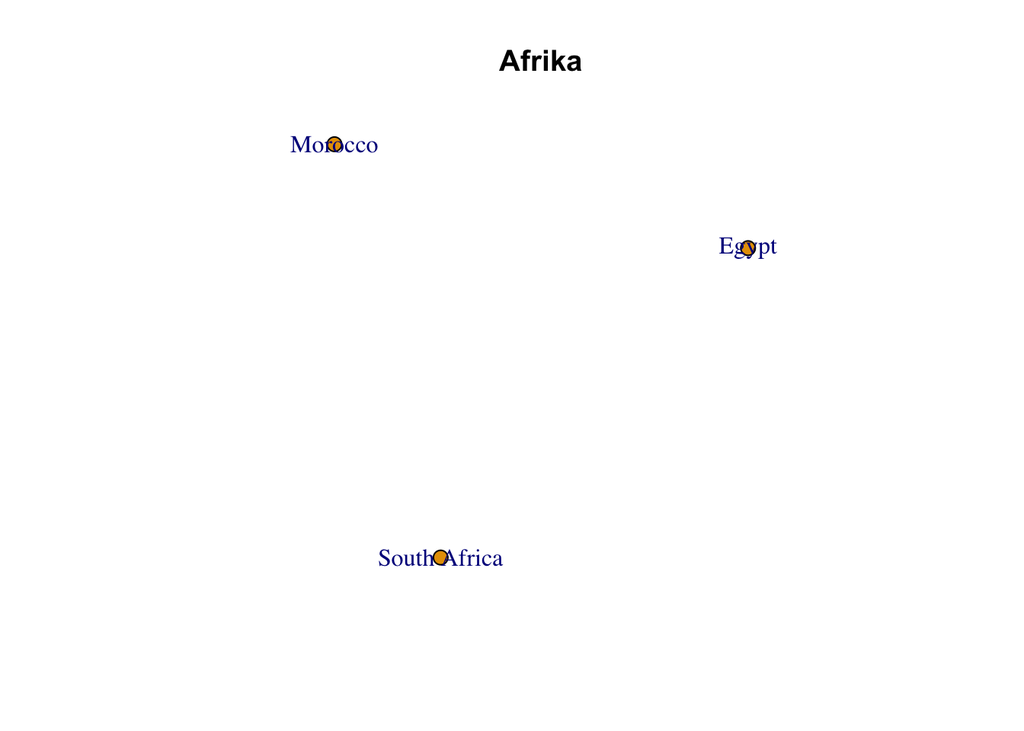

```r
layout = layout_with_graphopt(graph_AF)
plot(simplify(graph_AF), edge.arrow.size = 0.2,layout = layout, main = "Afrika")
```

In Afrika ensteht die Situation das keines der 3 Länder eine Beziehung hat, daraus kann man schließen das es keine Konstelationen von Ländern gibt wo das eine Land maximal 10 mal so viele weine Beiträgt wie das andere. Somit haben wir hier ein Netzwerk ohne Beziehungen.

#### Süd Amerika

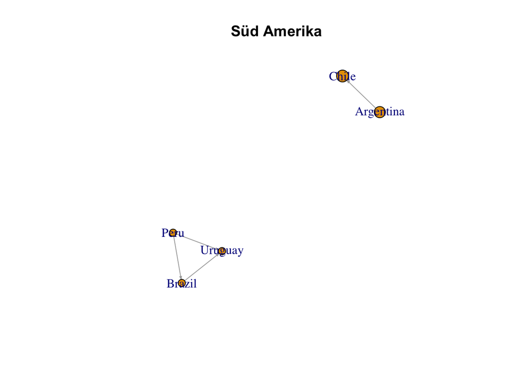

```r
layout = layout_with_graphopt(graph_SA)
plot(simplify(graph_SA), edge.arrow.size = 0.2,layout = layout, main = "Süd Amerika")
```

In Südamerika kommt es zu einer interessanten Clusterbildung, die beiden Länder Chile und Argentinien haben eine Verbindung, die beiden Länder sind auch auf dem Weltmarkt durchaus wichtige Produzenten. Ein weiterer Cluster bilden die Länder: Peru, Uruguay und Brazilien, kleinere Lateinamerikanische Länder welche nicht besonders relevant sind auf dem Weltmarkt, jedoch lässt sich aus dem Netzwerk ablesen das sie ein Dreieck bilden, dass bedeutet das sie ungefähr alle gleich viele Weine zum Datensatz beitragen.

#### Nord Amerika

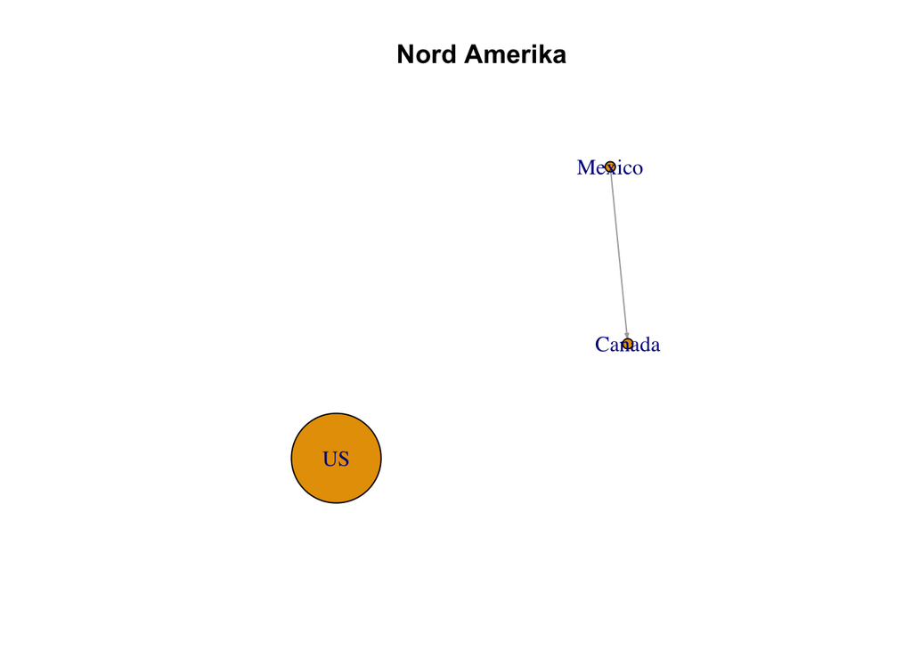

```r
layout = layout_with_graphopt(graph_NA)
plot(simplify(graph_NA), edge.arrow.size = 0.2,layout = layout, main = "Nord Amerika")
```

In Nord Amerika zeichnet sich ein zu erwartendes Bild ab, die USA stellen mit großem Abstand die meisten Weine, eine weitere Beziehung besteht zwar zwischen Mexico und Kanada, diese ist jedoch nicht von besonderer Bedeutung.

#### Ozianien

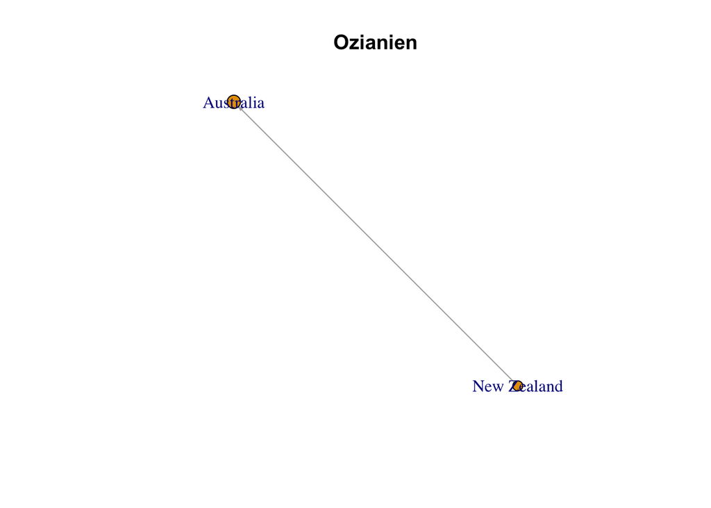

```r
layout = layout_with_graphopt(graph_OZ)
plot(simplify(graph_OZ), edge.arrow.size = 0.2,layout = layout, main = "Ozianien")
```

Abschließend sehen wir in Ozianien, nur die Bindung zwischen Australien und Neuseeland. Diese beiden Länder sind die einzigen die im Datensatz vom Kontinent Ozianien vertreten sind. Überaschenderweise ist Australien verhältnismäßig klein da es nicht besonder viele Weine dem Datensatz stellt. Auf dem Weltmarkt jedoch ist Australien eine wichtige Exportnation.

## Conclusio

Abschließend lassen sich folgende Erfgebnisse festhalten:

- Die USA sind das Land welches die meisten weine im Datensatz stellen: 54504 (41.9%)
- England hat mit 91,581 Punkten den höchsten Punktedurchschnitt im Datensatz wobei die USA mit 0.0133 den geringsten Standartfehler aufweisen
- Das beste Punkte zu Preis Verhältnis hat die Ukraine mit 9,124, am schlechtesten schneidet die Schweiz mit 1,039 ab
- Nach analyse der vertretenden Nationen sowie der Weltweiten Produktion von Wein lässt sich feststellen das der Datensatz einen starken USA-Bias hat und vor allem Weine aus den USA enthält
- Australische Weine unterproprtional viel Bewertet und Portugisische überproportional viel.
- In Europa sind zwei Cluster zu erkennen im Bezug auf die ähnlichkeit der Anzahl der Weine
  - Cluster 1 besteht vor allem aus kleineren West & mitteleuropäischen Staaten sowei dem Balkan und Osteuropa
  - Cluster 2 besteht aus den Großen Süd, West und Mitteleuropäischen Ländern
  - Griechenland liegt als Bindeglied zwischen den beiden
- In Asien sind keine Cluster zu erkennen nur Israel und die Türkei spielen eine wichtige Rolle da sie verhältnismäßig viel Produzieren
- In Afrika existiert keine Verbindung zwischen den Ländern da sie alle zu sehr unterschiedliche mengen an Wein zum Datensatz beitragen
- in Süd Amerika existieren 2 Cluster:
  - Cluster 1 bestehend aus Argentienen und Chile, zwei auch weltweit bedeutende Weinexportnationen
  - Cluster 2 besteht aus Uruguay, Brazilien und Peru welche jeweils ähnlich viel beitragen aber aus weltweiter Perspektive eher unerheblich sind
- In Nordamerika ist nur die Dominanz der USA im Datensatz abzusehen sowie eine nicht besonders wichtige verbindung zwischen mexico und Kanada
- In Ozianien kann man nur die Verbindung zwischen Australien und Neuseeland sehen da diese Länder die einzigen beiden aus der Region sind die im Datensatz vertreten sind
  - Australien sollte aufgrund seiner wichtigen Rolle auf dem Weltmarkt eigentlich eine größere Menge an weinen Stellen